# Project 2: Data Mining, Classification, Prediction

### Dimensionality Reduction with PCA

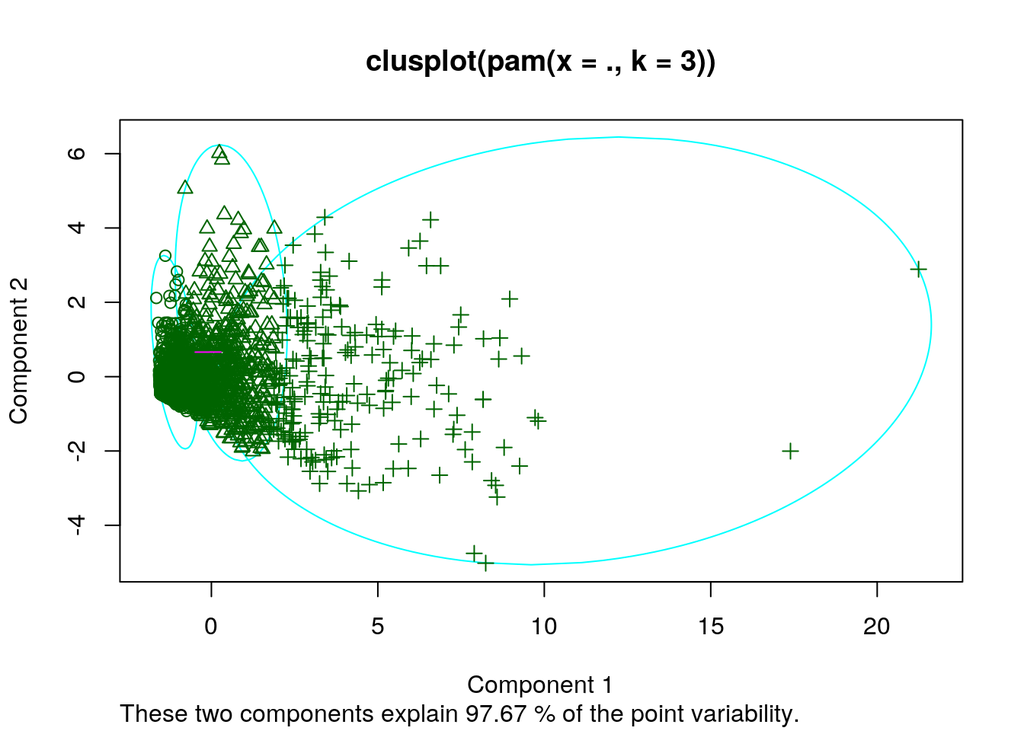

```r
plot(pam1, which = 1)
```

```r
library(tidyverse)

trying <- bechdel1 %>% select(-test)

trying1 <- bechdel1 %>% mutate(final_result = ifelse(final_result ==
    "FAIL", 0, 1))
glimpse(trying1)
```

```
## Rows: 1,777
## Columns: 9
## $ year               <int> 2013, 2012, 2013, 2013, 2013, 2013, 2013, 2013, 201…
## $ title              <chr> "21 & Over", "Dredd 3D", "12 Years a Slave", "2 Gun…
## $ test               <ord> notalk, ok, notalk, notalk, men, men, notalk, ok, o…
## $ final_result       <dbl> 0, 1, 0, 0, 0, 0, 0, 1, 1, 0, 1, 1, 1, 1, 0, 1, 0, …
## $ budget             <int> 13000000, 45000000, 20000000, 61000000, 40000000, 2…
## $ domgross           <dbl> 25682380, 13414714, 53107035, 75612460, 95020213, 3…
## $ intgross           <dbl> 42195766, 40868994, 158607035, 132493015, 95020213,…
## $ net_int_aftercosts <dbl> 29195766, -4131006, 138607035, 71493015, 55020213, …
## $ net_dom_aftercosts <dbl> 12682380, -31585286, 33107035, 14612460, 55020213, …
```

```r
trying1 <- trying1 %>% select(-year, -test)

bechdel_nums <- trying1 %>% select_if(is.numeric) %>% scale

bechdel_pca <- princomp(bechdel_nums)
names(bechdel_pca)
```

```
## [1] "sdev"     "loadings" "center"   "scale"    "n.obs"    "scores"   "call"
```

```r
summary(bechdel_pca, loadings = T)
```

```
## Importance of components:
##                           Comp.1    Comp.2    Comp.3     Comp.4       Comp.5
## Standard deviation     1.9755026 1.0413035 0.9453392 0.34063730 1.810169e-08
## Proportion of Variance 0.6508013 0.1808206 0.1490282 0.01934985 5.464263e-17
## Cumulative Proportion  0.6508013 0.8316219 0.9806501 1.00000000 1.000000e+00
##                        Comp.6
## Standard deviation          0
## Proportion of Variance      0
## Cumulative Proportion       1
##
## Loadings:
##                    Comp.1 Comp.2 Comp.3 Comp.4 Comp.5 Comp.6
## final_result               0.719  0.693
## budget             -0.330 -0.519  0.549  0.342  0.420  0.164
## domgross           -0.498                0.489 -0.516 -0.495
## intgross           -0.498         0.105 -0.418 -0.479  0.579
## net_int_aftercosts -0.494               -0.581  0.409 -0.494
## net_dom_aftercosts -0.385  0.451 -0.453  0.363  0.402  0.386
```

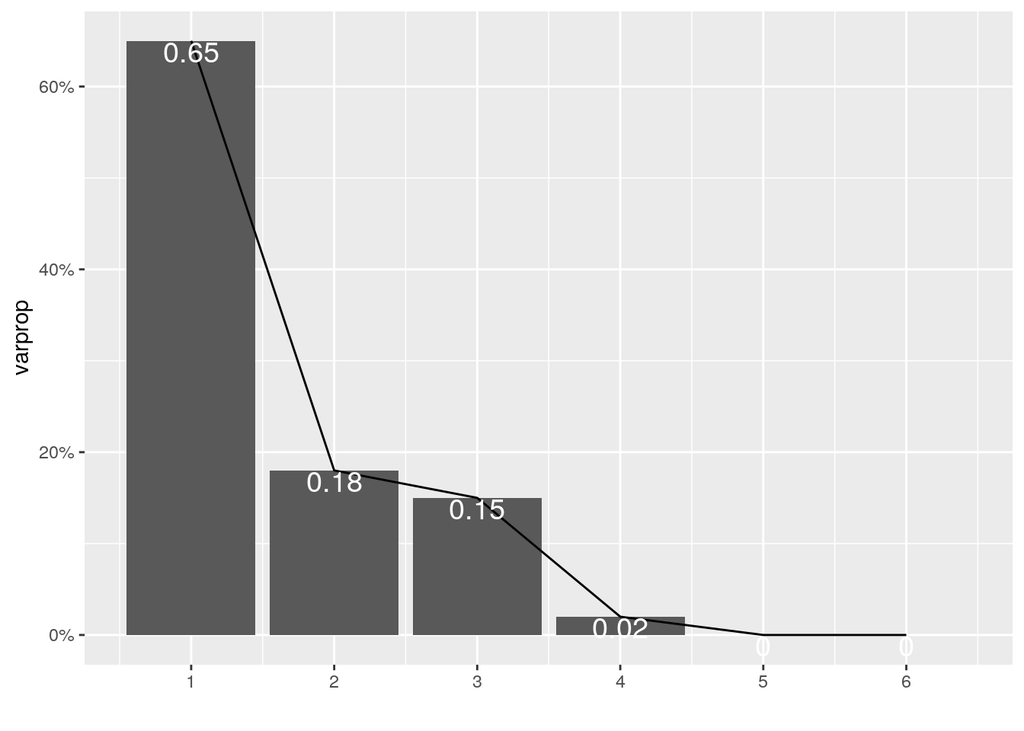

```r
# determining how many PCs to keep
eigval <- bechdel_pca$sdev^2
varprop = round(eigval/sum(eigval), 2)

ggplot() + geom_bar(aes(y = varprop, x = 1:6), stat = "identity") +
    xlab("") + geom_path(aes(y = varprop, x = 1:6)) + geom_text(aes(x = 1:6,
    y = varprop, label = round(varprop, 2)), vjust = 1, col = "white",
    size = 5) + scale_y_continuous(breaks = seq(0, 0.6, 0.2),
    labels = scales::percent) + scale_x_continuous(breaks = 1:10)
```

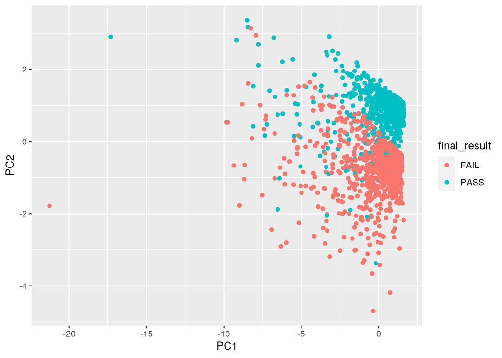

```r
# Keeping PC1 and PC2 & plotting them

bech_df <- data.frame(PC1 = bechdel_pca$scores[, 1], PC2 = bechdel_pca$scores[,
    2])
bech_df <- bech_df %>% mutate(final_result = trying$final_result)
ggplot(bech_df, aes(PC1, PC2)) + geom_point(aes(color = final_result))
```

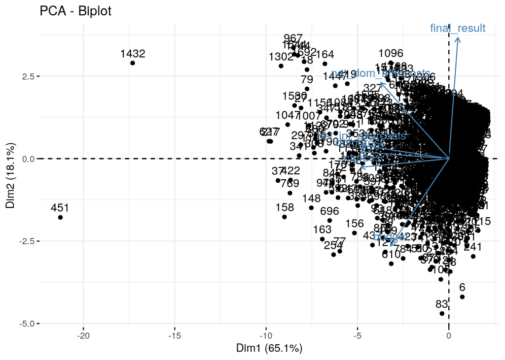

```r
# plotting biplot
library(factoextra)
fviz_pca_biplot(bechdel_pca)
```

My data’s standard deviations were converted to eig values, and I graphed the proportion of variation explained by each principle component. The second graph showed that PC1 accounted for 65% variation, PC2 accounted for 18% of the variation. It’s hard to tell from the biplot, but it appears that final_results of the bechdel test isn’t too correlated with revenue (numeric variables).

### Linear Classifier

```r
# linear classifier code here

trying <- bechdel1 %>% mutate(final_result = ifelse(final_result ==
    "FAIL", 0, 1))

fit <- glm(final_result ~ budget + intgross + domgross + net_int_aftercosts +
    net_dom_aftercosts, data = trying, family = "binomial")

summary(fit)
```

```
##
## Call:
## glm(formula = final_result ~ budget + intgross + domgross + net_int_aftercosts +
##     net_dom_aftercosts, family = "binomial", data = trying)
##
## Deviance Residuals:
##     Min       1Q   Median       3Q      Max
## -1.2866  -1.1142  -0.9091   1.2092   1.9154
##
## Coefficients: (2 not defined because of singularities)
##                      Estimate Std. Error z value Pr(>|z|)
## (Intercept)         9.876e-02  7.371e-02   1.340   0.1803
## budget             -7.186e-09  1.518e-09  -4.735 2.19e-06 ***
## intgross            1.721e-09  7.704e-10   2.234   0.0255 *
## domgross           -3.690e-09  1.834e-09  -2.012   0.0442 *
## net_int_aftercosts         NA         NA      NA       NA
## net_dom_aftercosts         NA         NA      NA       NA
## ---
## Signif. codes:  0 '***' 0.001 '**' 0.01 '*' 0.05 '.' 0.1 ' ' 1
##
## (Dispersion parameter for binomial family taken to be 1)
##
##     Null deviance: 2443.3  on 1776  degrees of freedom
## Residual deviance: 2407.7  on 1773  degrees of freedom
## AIC: 2415.7
##
## Number of Fisher Scoring iterations: 4
```

```r
score <- predict(fit, type = "response")
score %>% round(3)
```

```
##     1     2     3     4     5     6     7     8     9    10    11    12    13
## 0.496 0.449 0.508 0.404 0.407 0.196 0.429 0.527 0.492 0.346 0.424 0.467 0.441
##    14    15    16    17    18    19    20    21    22    23    24    25    26
## 0.491 0.422 0.475 0.393 0.466 0.504 0.351 0.318 0.365 0.429 0.421 0.486 0.360
##    27    28    29    30    31    32    33    34    35    36    37    38    39
## 0.332 0.328 0.420 0.469 0.383 0.367 0.481 0.475 0.414 0.508 0.318 0.231 0.474
##    40    41    42    43    44    45    46    47    48    49    50    51    52
## 0.464 0.429 0.518 0.495 0.197 0.495 0.433 0.355 0.375 0.204 0.282 0.467 0.466
##    53    54    55    56    57    58    59    60    61    62    63    64    65
## 0.493 0.388 0.435 0.305 0.386 0.458 0.480 0.450 0.449 0.429 0.467 0.213 0.474
##    66    67    68    69    70    71    72    73    74    75    76    77    78
## 0.462 0.498 0.479 0.499 0.494 0.360 0.459 0.478 0.232 0.394 0.401 0.262 0.436
##    79    80    81    82    83    84    85    86    87    88    89    90    91
## 0.284 0.457 0.420 0.511 0.147 0.421 0.499 0.412 0.520 0.507 0.397 0.378 0.485
##    92    93    94    95    96    97    98    99   100
## 0.428 0.312 0.504 0.334 0.460 0.436 0.290 0.253 0.419
##  [ reached getOption("max.print") -- omitted 1677 entries ]
```

```r
class_diag(score, truth = trying$final_result, positive = 1)
```

```
##            acc   sens   spec    ppv     f1     ba    auc
## Metrics 0.5571 0.2708 0.7884 0.5083 0.3533 0.5296 0.5853
```

```r
###

summary(fit$fitted.values)
```

```
##    Min. 1st Qu.  Median    Mean 3rd Qu.    Max.
##  0.1469  0.4142  0.4652  0.4468  0.4987  0.5629
```

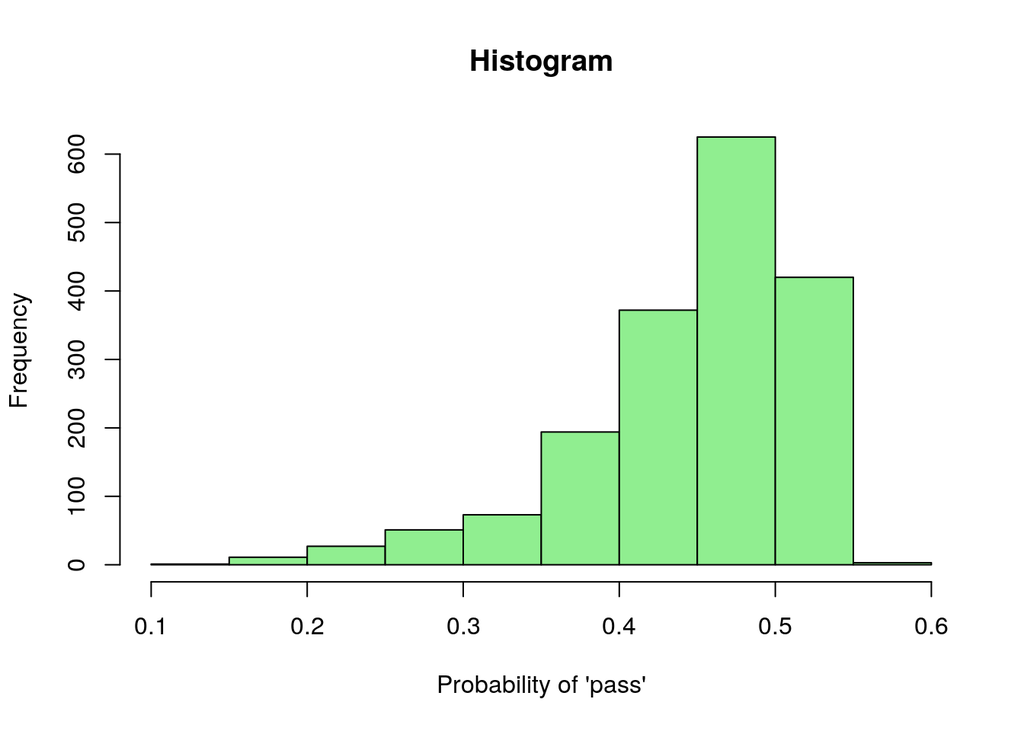

```r
hist(fit$fitted.values, main = " Histogram ", xlab = "Probability of 'pass'",
    col = "light green")
```

```r
fit$aic
```

```
## [1] 2415.688
```

```r
trying$Predict <- ifelse(fit$fitted.values > 0.5, "fail", "pass")

mytable <- table(trying$final_result, trying$Predict)
rownames(mytable) <- c("Obs. pass", "Obs. fail")
colnames(mytable) <- c("Pred. pass", "Pred. fail")
mytable
```

```
##
##             Pred. pass Pred. fail
##   Obs. pass        208        775
##   Obs. fail        215        579
```

```r
efficiency <- sum(diag(mytable))/sum(mytable)
efficiency
```

```
## [1] 0.4428813
```

```r
probability <- predict(fit, type = "response")
table(truth = trying$final_result, prediction = as.numeric(probability >
    0.5)) %>% addmargins
```

```
##      prediction
## truth    0    1  Sum
##   0    775  208  983
##   1    579  215  794
##   Sum 1354  423 1777
```

The variable final_result (pass/fail Bechdel test) was predicted with 55.71% accuracy, 27.08% sensitivity (proportion of actual passes being correctly identified), 78.84% specificity (proportion of actual fails being correctly identified), 50.83% positive predictive value (proportion of cases predicted passing that are actually passing), an F1 score of 35.33% (summarizing how well classification is), and an AUC of 58.53%. The in-sample testing here was pretty poor, indicating that the model is not really reliable in predicting new observations per CV AUC. The histogram shows a distribution of predicted probability of ‘pass’ for a movie in a Bechdel test.

```r
# cross-validation of linear classifier here

set.seed(1234)
k = 10  #choose number of folds

data <- trying[sample(nrow(trying)), ]  #randomly order rows
folds <- cut(seq(1:nrow(trying)), breaks = k, labels = F)  #create folds

diags <- NULL
for (i in 1:k) {
    ## Create training and test sets
    train <- data[folds != i, ]
    test <- data[folds == i, ]
    truth <- test$final_result  ## Truth labels for fold i

    ## Train model on training set (all but fold i)
    fit <- glm(final_result ~ budget + intgross + domgross +
        net_int_aftercosts + net_dom_aftercosts, data = trying,
        family = "binomial")

    ## Test model on test set (fold i)
    probs <- predict(fit, newdata = test, type = "response")

    ## Get diagnostics for fold i
    diags <- rbind(diags, class_diag(probs, truth, positive = 1))
}

summarize_all(diags, mean)
```

```
##       acc    sens    spec     ppv      f1      ba     auc
## 1 0.55713 0.26869 0.78868 0.50551 0.34965 0.52867 0.58501
```

### Non-Parametric Classifier

```r
library(caret)

# non-parametric classifier code here

fit <- knn3(final_result ~ ., data = trying)
probs <- predict(fit, newdata = trying)[, 2]
class_diag(probs, trying$final_result, positive = "1")
```

```
##            acc   sens   spec    ppv     f1     ba    auc
## Metrics 0.7136 0.6398 0.7731 0.6949 0.6662 0.7065 0.7764
```

```r
table(truth = trying$final_result, prediction = (probability >
    0.5)) %>% addmargins()
```

```
##      prediction
## truth FALSE TRUE  Sum
##   0     775  208  983
##   1     579  215  794
##   Sum  1354  423 1777
```

```r
# cross-validation of np classifier here
set.seed(1234)
k = 10  #choose number of folds

data <- trying[sample(nrow(trying)), ]  #randomly order rows
folds <- cut(seq(1:nrow(trying)), breaks = k, labels = F)  #create 10 folds

diags <- NULL
for (i in 1:k) {
    ## Create training and test sets
    train <- data[folds != i, ]
    test <- data[folds == i, ]
    truth <- test$final_result

    ## Train model on training set
    fit1 <- knn3(final_result ~ budget + intgross + domgross +
        net_int_aftercosts + net_dom_aftercosts, data = trying)
    probs <- predict(fit1, newdata = test)[, 2]

    ## Test model on test set (save all k results)
    diags <- rbind(diags, class_diag(probs, truth, positive = 1))
}

summarize_all(diags, mean)
```

```
##       acc    sens    spec     ppv      f1      ba     auc
## 1 0.71358 0.63956 0.77301 0.69368 0.66521 0.70628 0.77591
```

The level of fit shown by the results is average-good. With higher values across the board, it appears that there are minimal signs of overfitting.

### Regression/Numeric Prediction

```r
# regression model code here
fit <- lm(net_dom_aftercosts ~ domgross + budget, data = trying)  #predict mpg from all other variables
yhat <- predict(fit)  #predicted mpg

mean((trying$net_dom_aftercosts - yhat)^2)
```

```
## [1] 4.777801e-14
```

```r
# cross-validation of regression model here

set.seed(1234)
k = 5  #choose number of folds
data <- trying[sample(nrow(trying)), ]  #randomly order rows
folds <- cut(seq(1:nrow(trying)), breaks = k, labels = F)  #create folds
diags <- NULL
for (i in 1:k) {
    train <- data[folds != i, ]
    test <- data[folds == i, ]
    ## Fit linear regression model to training set
    fit <- lm(net_dom_aftercosts ~ domgross + budget, data = train)
    ## Get predictions/y-hats on test set (fold i)
    yhat <- predict(fit, newdata = test)
    ## Compute prediction error (MSE) for fold i
    diags <- mean((test$net_dom_aftercosts - yhat)^2)
}
mean(diags)
```

```
## [1] 5.324899e-14
```

### Python

```r
library(reticulate)
use_python("/usr/bin/python3", required = F)
hi <- "Hook"

cat(c(hi, py$hi))
```

```
## Hook
```

```python
# python code here

hi = "em"

print(r.hi,hi)
```

```
## Hook em
```

Discussion

In the R chunk, we assign “Hook” to hi. In the python chunk above, we can assign “em” to hi.